# Project University Art Collection

Ivan Pogorelov

# Analysis of an art museum catalog to identify inconsistencies, clean the data, and derive insights.

### Load packages and data

```r
# Load necessary libraries
# tidyverse: A collection of R packages for data manipulation and visualization
# skimr: A package for summarizing data structures and exploring missing data
library(tidyverse)
library(skimr)
```

```r
# Load the art museum catalog data from a CSV file.
# The eval argument is set to FALSE to avoid errors if the file is not yet available.
# Change eval to TRUE when the file path is set correctly.
art <- read_csv("data/art.csv")
```

### Exercise 9

Clean and transform the art dataset by separating the title and year.  
Extract the year from the “Title” column and remove parentheses.  
Convert the extracted year into a numeric format for analysis.  
Select relevant columns (`Title`, `Artist`, `Year`, `Link`) for further analysis.

```r
art <- art %>%
  # Split the Title column into "Title" and "Year" based on the opening parenthesis "("
  separate(Title, into = c("Title", "Year"), sep = "\\(", fill = "right") %>%
  # Remove the closing parenthesis ")" from the Year column
  mutate(Year = str_remove(Year, "\\)")) %>%
  # Convert the Year column to numeric format
  mutate(Year = as.numeric(Year)) %>%
  # Retain only the necessary columns
  select(Title, Artist, Year, Link)
# Preview the cleaned dataset
head(art)
```

```
## # A tibble: 6 × 4
##   Title                                     Artist              Year Link
##   <chr>                                     <chr>              <dbl> <chr>
## 1 "Untitled "                               Richard Easson      1969 https://co…
## 2 "Untitled "                               Pamela Richardson   1987 https://co…
## 3 "Abstract Composition with Blue Stripes " Ian G. Robertson    1969 https://co…
## 4 "Untitled - Abstract Road "               Laura McPherson     1965 https://co…
## 5 "Nude Woman Standing "                    Rose A. K. Forsyth  1961 https://co…
## 6 "Light Around Limbo "                     Joseph Glover       2016 https://co…
```

### Exercise 10

Summarize the dataset to identify missing values.

```r
# Summary of the art dataset, including missing data patterns
skim(art)
```

Data summary

| Name | art |
| --- | --- |
| Number of rows | 1970 |
| Number of columns | 4 |
| _______________________ |  |
| Column type frequency: |  |
| character | 3 |
| numeric | 1 |
| ________________________ |  |
| Group variables | None |

**Variable type: character**

| skim_variable | n_missing | complete_rate | min | max | empty | n_unique | whitespace |
| --- | --- | --- | --- | --- | --- | --- | --- |
| Title | 0 | 1.00 | 0 | 95 | 3 | 1000 | 0 |
| Artist | 68 | 0.97 | 4 | 466 | 0 | 873 | 0 |
| Link | 0 | 1.00 | 59 | 60 | 0 | 1970 | 0 |

**Variable type: numeric**

| skim_variable | n_missing | complete_rate | mean | sd | p0 | p25 | p50 | p75 | p100 | hist |
| --- | --- | --- | --- | --- | --- | --- | --- | --- | --- | --- |
| Year | 943 | 0.52 | 1966.16 | 24.97 | 1819 | 1953 | 1962 | 1981 | 2020 | ▁▁▁▇▃ |

**Findings:** - 68 pieces are missing artist information. - 943 pieces are missing year information. - These issues highlight data inconsistencies that need further investigation.

### Exercise 11

Visualize the distribution of artwork years to understand historical trends.  
A histogram is used to show the count of artworks grouped by decades.

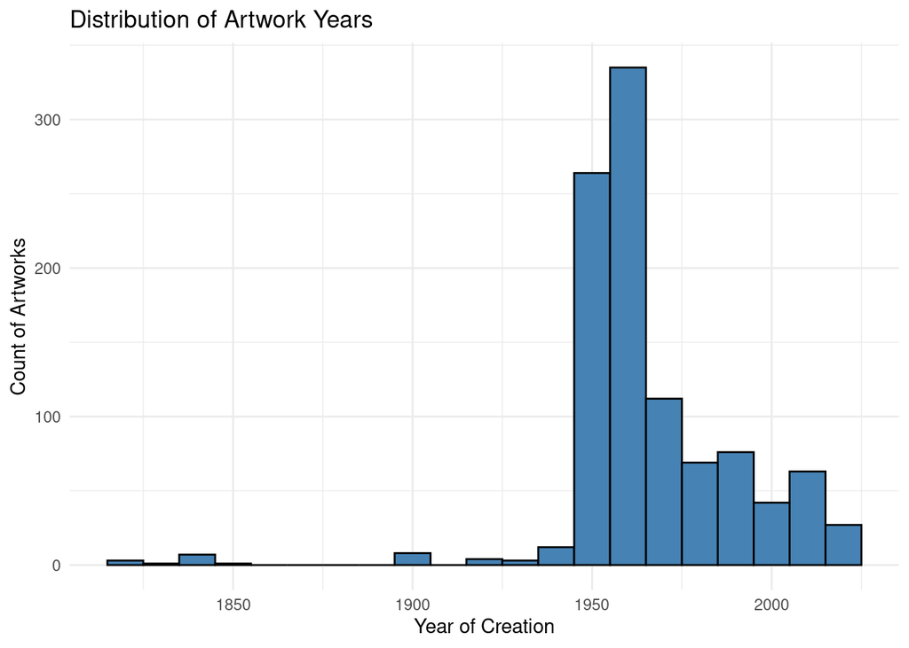

```r
art %>%
  ggplot(aes(x = Year)) +
  # Use geom_histogram to create a histogram with binwidth set to 10 years
  geom_histogram(binwidth = 10, fill = "steelblue", color = "black") +
  labs(title = "Distribution of Artwork Years",
       x = "Year of Creation",
       y = "Count of Artworks") +
  theme_minimal()
```

### Exercise 12

Note a specific inconsistency in the data:  
“Death Mask (2) (1964)” incorrectly captures the year as `2` instead of `1964`.  
This indicates a parsing error when separating the title and year.

### Exercise 13

Identify the second most common artist in the collection.

```r
most_common_artist <- art %>%
  group_by(Artist) %>%         # Group by artist
  summarize(Count = n()) %>%   # Count the number of artworks per artist
  arrange(desc(Count)) %>%     # Sort by count in descending order
  slice(2) %>%                 # Select the second most common artist
  ungroup()                    # Ungroup the dataset for clarity

# Display the result
most_common_artist
```

```
## # A tibble: 1 × 2
##   Artist       Count
##   <chr>        <int>
## 1 Emma Gillies   111
```

### Exercise 14

Count the number of artworks with “child” in the title.  
Use a case-insensitive search to identify matches.

```r
count_with_child <- art %>%
  # Filter titles that contain the word "child" (case-insensitive)
  filter(str_detect(Title, regex("child", ignore_case = TRUE))) %>%
  # Count the number of matching rows
  count()

# Display the count
count_with_child
```

```
## # A tibble: 1 × 1
##       n
##   <int>
## 1     4
```

### Exercise 15

Visualize the distribution of the number of artworks by artist.  
Create a bar plot to identify the most prolific artists.

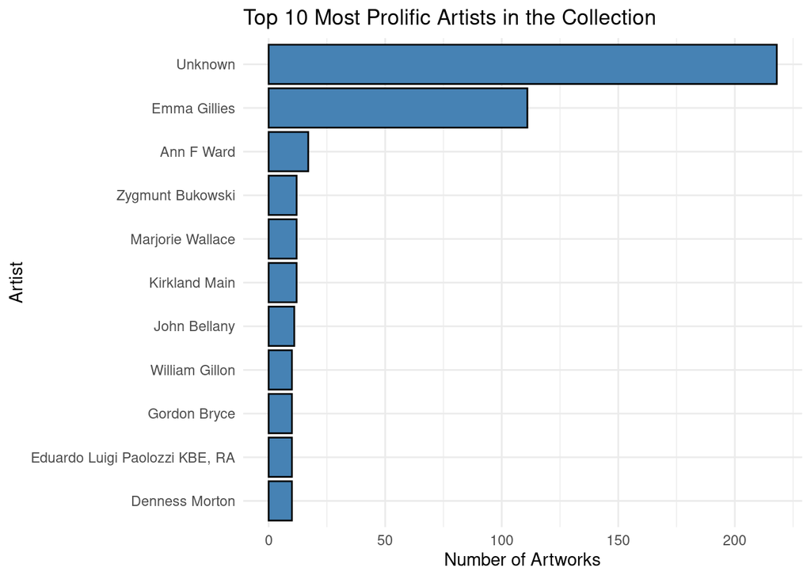

```r
art %>%
  group_by(Artist) %>%
  summarize(Count = n()) %>%
  arrange(desc(Count)) %>%
  filter(!is.na(Artist)) %>%  # Filter out missing artist names
  top_n(10, Count) %>%        # Select the top 10 artists by count
  ggplot(aes(x = reorder(Artist, Count), y = Count)) +
  geom_bar(stat = "identity", fill = "steelblue", color = "black") +
  coord_flip() +
  labs(title = "Top 10 Most Prolific Artists in the Collection",
       x = "Artist",
       y = "Number of Artworks") +
  theme_minimal()
```

### Exercise 16

Visualize the relationship between the year of creation and the number of artworks.  
Create a scatter plot to identify trends over time.

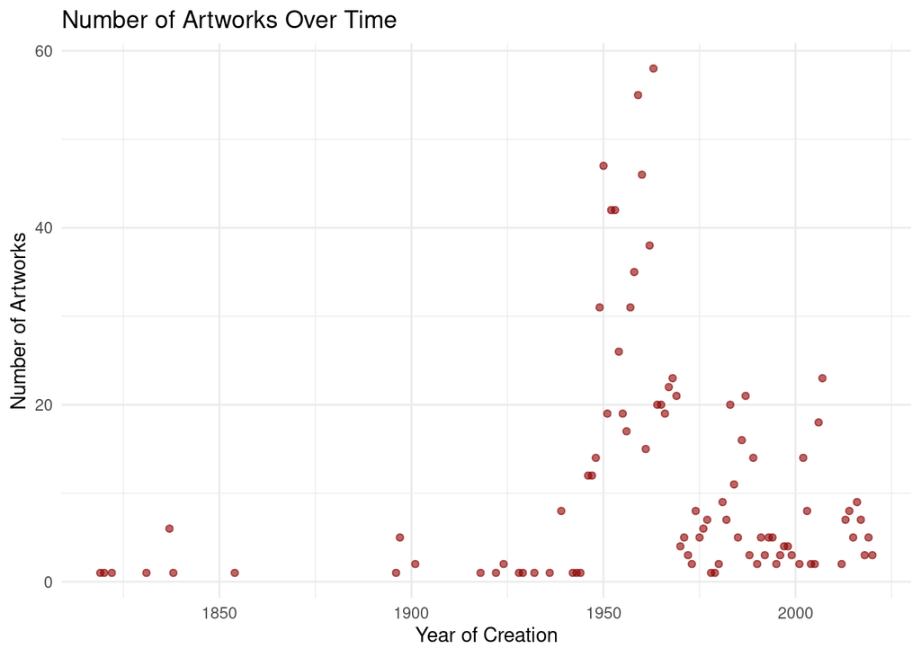

```r
art %>%
  filter(!is.na(Year)) %>%  # Filter out missing year values
  ggplot(aes(x = Year)) +
  geom_point(stat = "count", color = "darkred", alpha = 0.6) +
  labs(title = "Number of Artworks Over Time",
       x = "Year of Creation",
       y = "Number of Artworks") +
  theme_minimal()
```

### Exercise 17

Create a heatmap to visualize the missing data patterns.  
This helps to understand where data is missing and informs data cleaning efforts.

```r
library(reshape2)
```

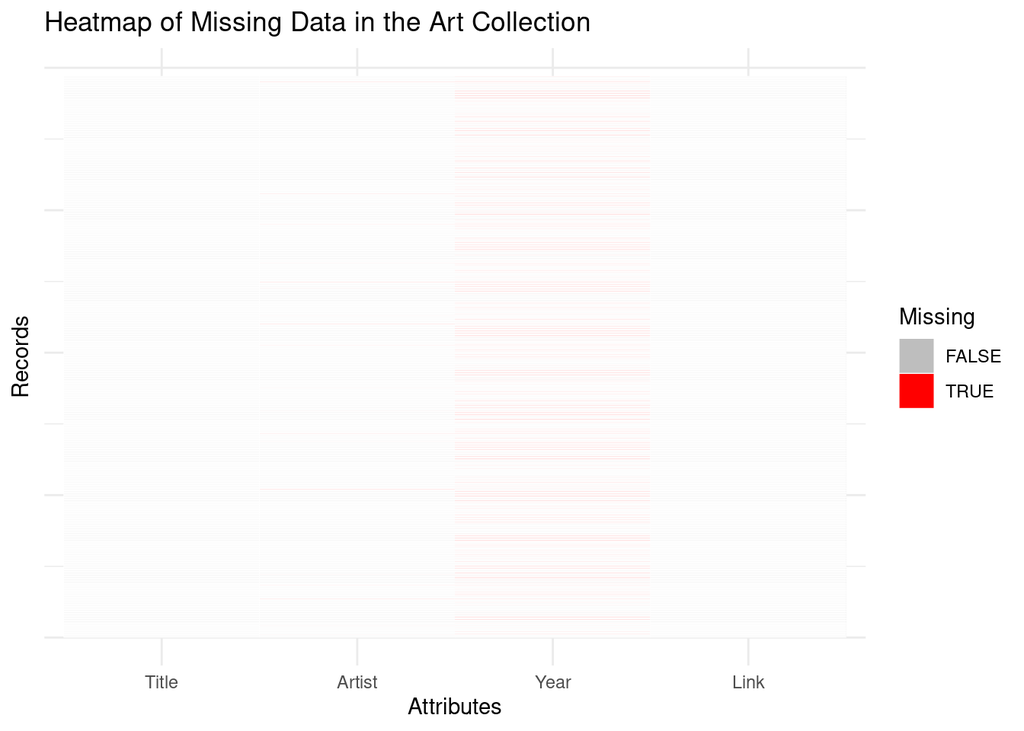

```r
# Create a logical matrix of missing data
missing_data <- is.na(art)

# Convert the matrix into a dataframe for visualization
missing_data_melted <- melt(missing_data)

# Plot a heatmap of missing data
missing_data_melted %>%
  ggplot(aes(x = Var2, y = Var1, fill = value)) +
  geom_tile(color = "white") +
  scale_fill_manual(values = c("TRUE" = "red", "FALSE" = "grey")) +
  labs(title = "Heatmap of Missing Data in the Art Collection",
       x = "Attributes",
       y = "Records",
       fill = "Missing") +
  theme_minimal() +
  theme(axis.text.y = element_blank(),
        axis.ticks.y = element_blank())
```

### Notes

- **Project Objective**: Analyze and clean a university art museum catalog.
- **Key Issues**:
  - Missing data: Several records lack artist or year information.
  - Parsing errors: Some entries have incorrect year extraction due to inconsistencies in the “Title” format.
- **Next Steps**:
  - Investigate records with missing data.
  - Manually correct prominent errors, such as “Death Mask (2) (1964).”
  - Explore trends in the dataset, such as the most common themes or prolific artists.